# ’John Hopkins University Data Science Specialiazition Capstone Project: Milestone Report 1

Steffen Hartleib

July 21, 2015

## Overview

The project assignment is to create an app that takes a string of words from a user and predicts the next word.  
This initial report explores the data and briefly describes the next steps in building the model.

## The raw data

The corpus is three large sets of English language data:

n_US.news.txt – 196M  
en_US.blogs.txt – 196M  
en_US.twitter.txt – 196M

## Line counts and size of sample files

```
##           News Blogs Twitter
## Size(MB)     1    10       0
## LineCount 5000 45183    5000
```

These sample files make up the corpora for the rest of the analysis.

## Cleaning the data

- removed punctuation
- removed any non alphabetical charcters
- kept dashes and apostrophes within words
- added periods back to most frequent abreviations
- converted all words to lower case
- removed profanties

## Tokinizing the data sets

created frequency tables of:  
* single words  
* 2-word phrases (bigrams)  
* 3-word phrases(trigrams)

## Single words

- The corpus of sample files includes:
- 1.3 Million instances made up of about 72k distinct words
- The average frequency is 19
- The the median frequency is 2
- The data is highly skewed by a few highfrequency words such as “the”, “and”.
- Since the assignemnt is to predict the next word, I did not remove these stop words.

## Here are the 25 most frequent words

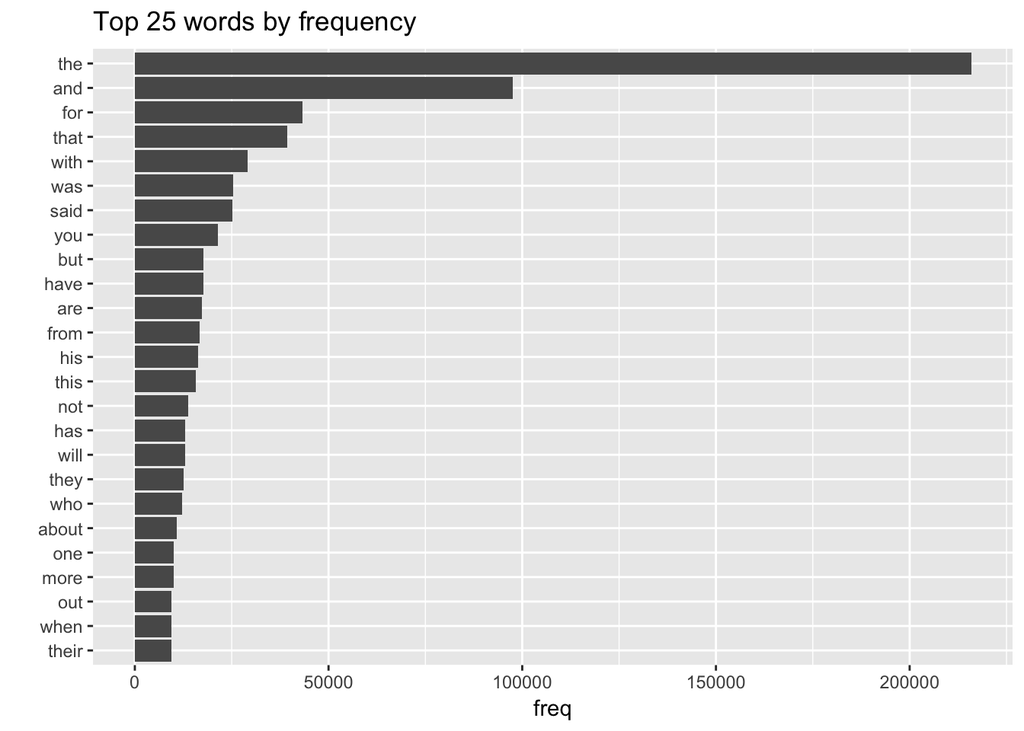

## Frequency distribution

To make the chart more legible I zoomed in on frequencies between 1,000 and 10,000. Still the data remains highl skewed.

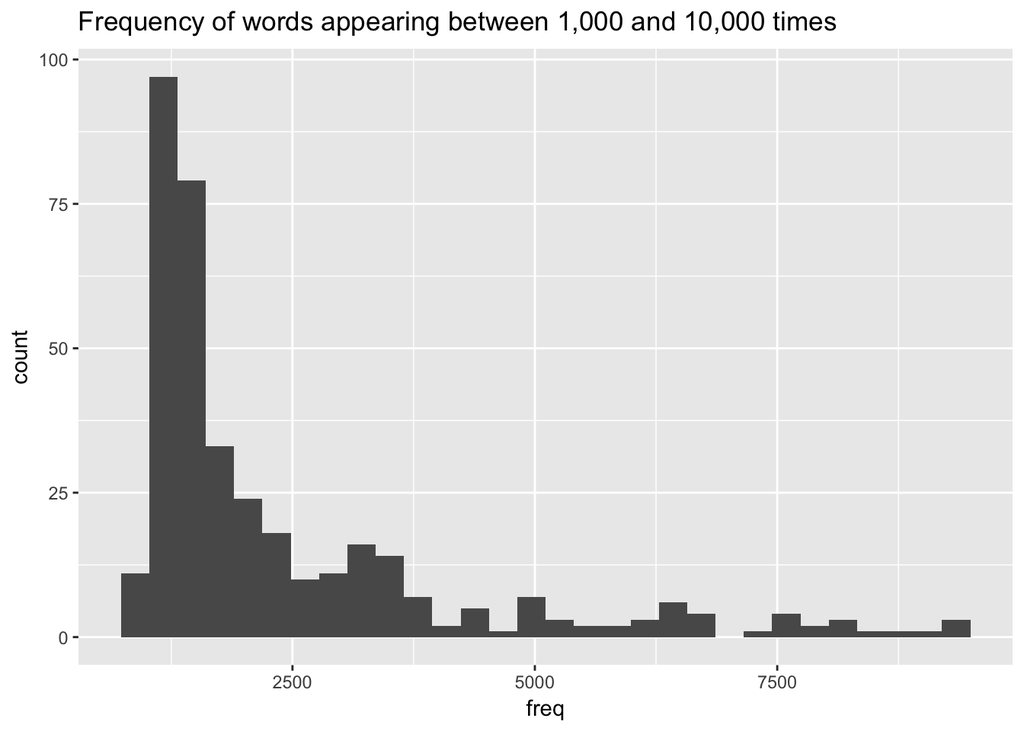

## How many unique words does it take to cover 50% and 90% of the instances?

Because the data is so heavily skewed towards high frequency words, it takes only 375 words to cover 50% of the instances. 10,000 words will get you to 90% coverage:

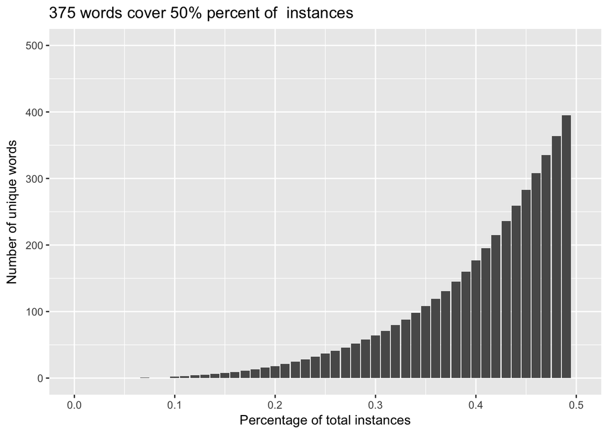

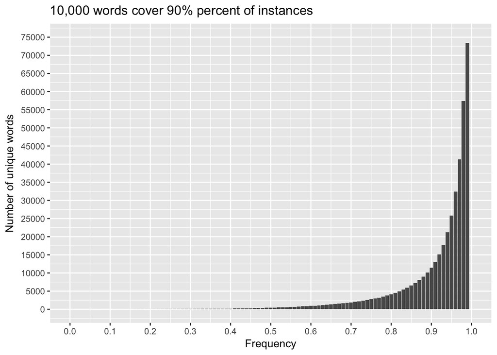

## Here are the 25 most frequent biGrams:

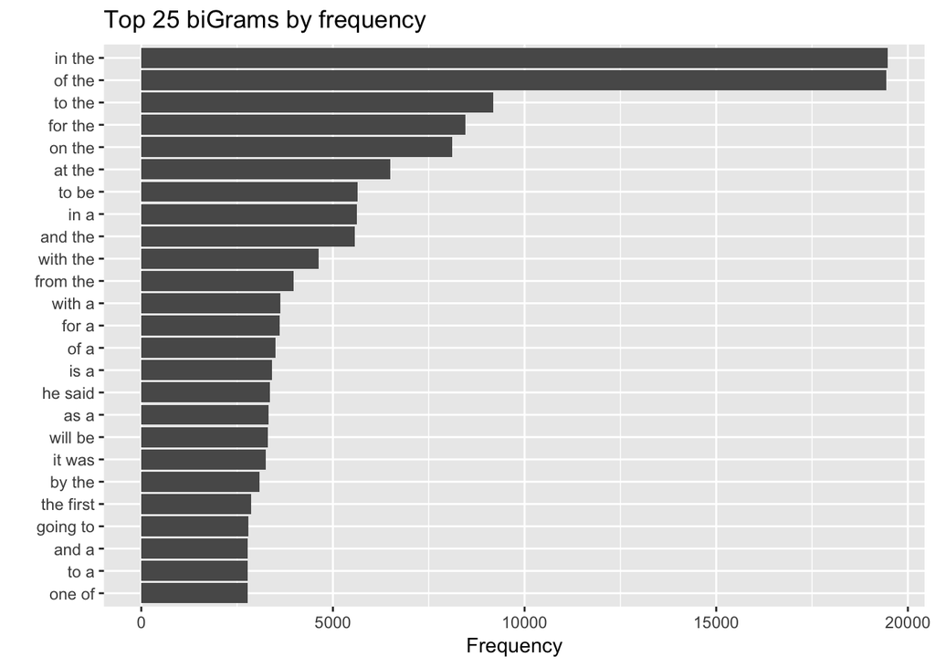

## Frequency distribution:

Again, to make the chart more legible, I zoomed in on frequencies over 1,000

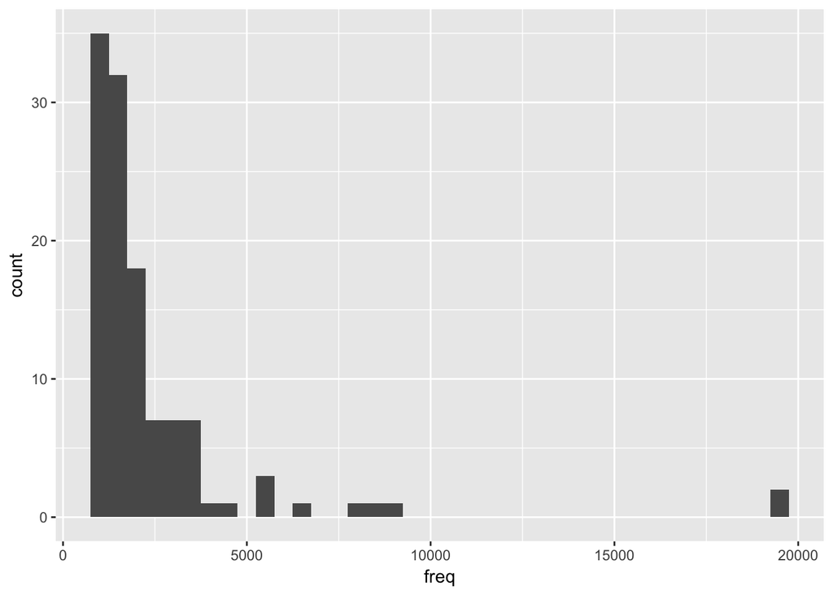

## How many unique biGrams will cover 50% and 90% of the instances?

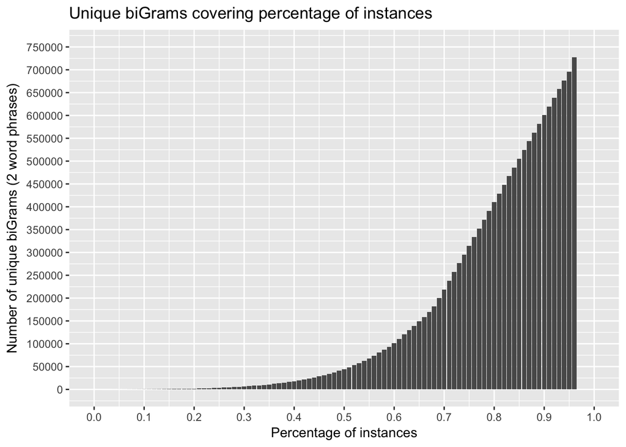

## Here are the top 25 trigrams:

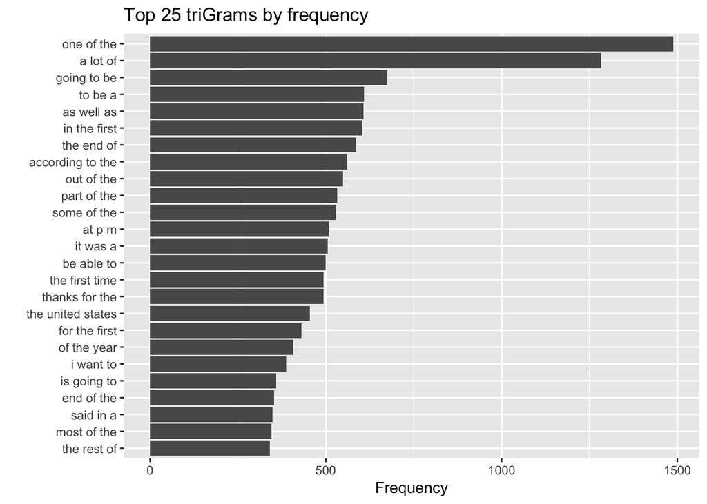

## Frequency distribution of trigrams

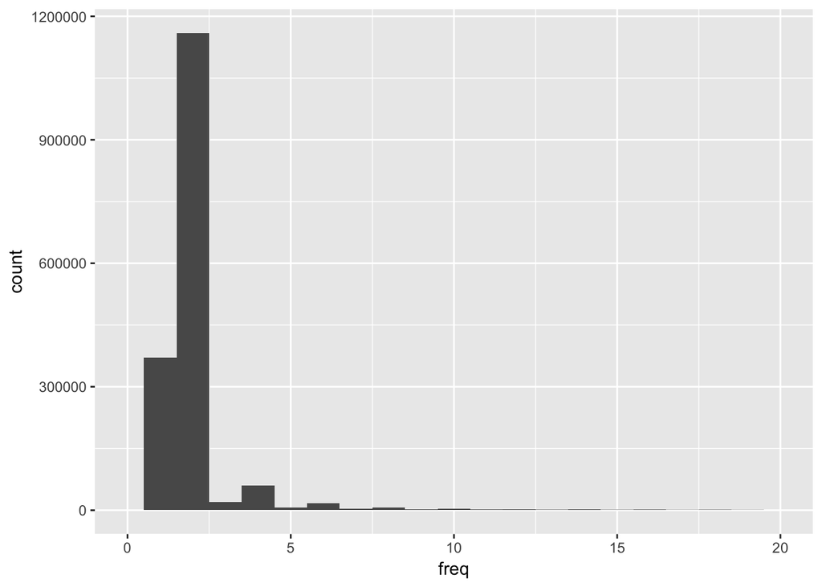

## How many unique triGrams will cover 50% and 90% of the instances?

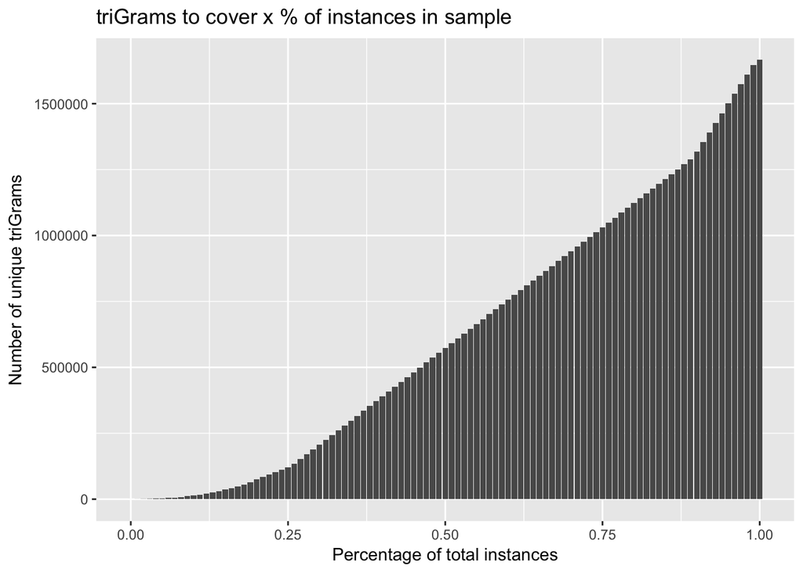